# data_cleaning

# Conducting paired t-test

```r
average_duration[average_duration$dominant == 'synchronous',]
```

| subject | sync_side | dominant | average_duration |
| --- | --- | --- | --- |
| 1 | left | synchronous | 1.5381747 |
| 1 | right | synchronous | 2.0408492 |
| 2 | left | synchronous | 3.2204919 |
| 2 | right | synchronous | 3.1850272 |
| 3 | left | synchronous | 4.4514676 |
| 3 | right | synchronous | 3.4017917 |
| 4 | left | synchronous | 4.8506552 |
| 4 | right | synchronous | 2.8405700 |
| 5 | left | synchronous | 3.1788764 |
| 5 | right | synchronous | 2.5374043 |

[output cut: 98 more lines]

```r
average_duration[average_duration$dominant == 'synchronous',]$average_duration
```

```
##   [1] 1.5381747 2.0408492 3.2204919 3.1850272 4.4514676 3.4017917 4.8506552
##   [8] 2.8405700 3.1788764 2.5374043 1.5669746 0.9558916 1.3458174 1.9246347
##  [15] 4.0288723 4.3904742 1.7714777 2.0256165 9.5714462 9.6705168 3.2625604
##  [22] 2.6489501 2.1240639 2.0469255 1.3510059 1.1711681 2.1362545 2.0999013
##  [29] 2.0662479 1.9612535 2.4456740 2.4342911 2.6635223 4.2484459 2.5605051
##  [36] 3.1142330 2.1455448 1.9104911 1.3568758 1.9318725 2.7010978 2.5068611
##  [43] 3.4209738 3.1640848 3.5305408 3.3248775 1.3456866 1.7584931 2.1389284
##  [50] 3.4488301 2.4371686 3.4253482 3.3569464 3.7313941 2.4876966 1.8755009
##  [57] 2.8590758 2.7361171 2.9254591 4.1643049 3.0878120 3.3932337 2.1778271
##  [64] 2.6439639 3.6703511 3.9003531 2.4664165 1.7883432 1.7605971 2.7407622
##  [71] 2.8004603 3.1746675 2.2277481 3.0630598 1.5832928 2.2509029 3.3293866
##  [78] 3.4913722 2.4428135 2.2652230 2.3625592 2.5137992 1.4868848 2.5909928
##  [85] 3.1837988 3.0241852 3.7446250 2.8173249 2.2501946 2.4943194 1.5512955
##  [92] 3.8479834 2.1046538 2.2514526 1.9905369 2.1788844 2.6446685 3.6543530
##  [99] 1.6248060 1.7305125 3.0733311 3.1033745 4.7708524 3.0321966 2.8552472
## [106] 2.4388150 2.1283307 2.1719119
```

```r
sync <- average_duration[average_duration$dominant == 'synchronous',]$average_duration
async <- average_duration[average_duration$dominant == 'asynchronous',]$average_duration
t.test(sync, async, paired = TRUE)
```

```
##
##  Paired t-test
##
## data:  sync and async
## t = 1.7111, df = 107, p-value = 0.08997
## alternative hypothesis: true mean difference is not equal to 0
## 95 percent confidence interval:
##  -0.01856601  0.25273600
## sample estimates:
## mean difference
##        0.117085
```

# Conducting one way t-test

```r
t.test(sync, async, paired = TRUE, alternative = 'greater')
```

```
##
##  Paired t-test
##
## data:  sync and async
## t = 1.7111, df = 107, p-value = 0.04498
## alternative hypothesis: true mean difference is greater than 0
## 95 percent confidence interval:
##  0.003547533         Inf
## sample estimates:
## mean difference
##        0.117085
```

# conducting Generalized Linear Mixed-Effects Models dominant + subject

```r
fit <- glmer(duration ~ dominant + (1 + dominant|subject),
             family = Gamma(link = 'log'),
             data = filtered_data)
summary(fit)
```

```
## Generalized linear mixed model fit by maximum likelihood (Laplace
##   Approximation) [glmerMod]
##  Family: Gamma  ( log )
## Formula: duration ~ dominant + (1 + dominant | subject)
##    Data: filtered_data
##
##      AIC      BIC   logLik deviance df.resid
##  84544.1  84593.2 -42266.0  84532.1    26361
##
## Scaled residuals:
##     Min      1Q  Median      3Q     Max
## -1.4156 -0.5947 -0.2137  0.3059 22.6403
##
## Random effects:
##  Groups   Name                Variance Std.Dev. Corr
##  subject  (Intercept)         0.049968 0.22353
##           dominantsynchronous 0.006019 0.07758  0.05
##  Residual                     0.476495 0.69029
## Number of obs: 26367, groups:  subject, 54
##
## Fixed effects:
##                     Estimate Std. Error t value Pr(>|z|)
## (Intercept)          0.92288    0.04369  21.123   <2e-16 ***
## dominantsynchronous  0.02574    0.01509   1.705   0.0881 .
## ---
## Signif. codes:  0 '***' 0.001 '**' 0.01 '*' 0.05 '.' 0.1 ' ' 1
##
## Correlation of Fixed Effects:
##             (Intr)
## dmnntsynchr 0.056
```

# conducting Generalized Linear Mixed-Effects Models dominant + subject

```r
fit1 <- glmer(duration ~ dominant + (1|subject),
              family = Gamma(link = 'log'),
              data = filtered_data)
summary(fit1)
```

```
## Generalized linear mixed model fit by maximum likelihood (Laplace
##   Approximation) [glmerMod]
##  Family: Gamma  ( log )
## Formula: duration ~ dominant + (1 | subject)
##    Data: filtered_data
##
##      AIC      BIC   logLik deviance df.resid
##  84599.8  84632.6 -42295.9  84591.8    26363
##
## Scaled residuals:
##     Min      1Q  Median      3Q     Max
## -1.4094 -0.5926 -0.2122  0.3085 22.7225
##
## Random effects:
##  Groups   Name        Variance Std.Dev.
##  subject  (Intercept) 0.05314  0.2305
##  Residual             0.48057  0.6932
## Number of obs: 26367, groups:  subject, 54
##
## Fixed effects:
##                     Estimate Std. Error t value Pr(>|z|)
## (Intercept)         0.927540   0.045024  20.601  < 2e-16 ***
## dominantsynchronous 0.019123   0.007245   2.639  0.00831 **
## ---
## Signif. codes:  0 '***' 0.001 '**' 0.01 '*' 0.05 '.' 0.1 ' ' 1
##
## Correlation of Fixed Effects:
##             (Intr)
## dmnntsynchr -0.081
```

# conducting Generalized Linear Mixed-Effects Models key + subject

```r
fit2 <- glmer(duration ~ dominant +  key + (1 + key|subject),
             family = Gamma(link = 'log'),
             data = filtered_data)
summary(fit2)
```

```
## Generalized linear mixed model fit by maximum likelihood (Laplace
##   Approximation) [glmerMod]
##  Family: Gamma  ( log )
## Formula: duration ~ dominant + key + (1 + key | subject)
##    Data: filtered_data
##
##      AIC      BIC   logLik deviance df.resid
##  84140.0  84197.3 -42063.0  84126.0    26360
##
## Scaled residuals:
##     Min      1Q  Median      3Q     Max
## -1.4193 -0.5876 -0.2078  0.3101 22.3087
##
## Random effects:
##  Groups   Name        Variance Std.Dev. Corr
##  subject  (Intercept) 0.05704  0.2388
##           keyright    0.02121  0.1456   -0.29
##  Residual             0.47277  0.6876
## Number of obs: 26367, groups:  subject, 54
##
## Fixed effects:
##                     Estimate Std. Error t value Pr(>|z|)
## (Intercept)         0.906608   0.046824  19.362  < 2e-16 ***
## dominantsynchronous 0.019277   0.007174   2.687  0.00721 **
## keyright            0.032863   0.027494   1.195  0.23198
## ---
## Signif. codes:  0 '***' 0.001 '**' 0.01 '*' 0.05 '.' 0.1 ' ' 1
##
## Correlation of Fixed Effects:
##             (Intr) dmnnts
## dmnntsynchr -0.077
## keyright    -0.282  0.000
```

```r
# Extract p-values
p_values <- summary(fit2)$coefficients[, "Pr(>|z|)"]

# Extract the p-value for 'dominantsynchronous'
p_value_dominantsynchronous <- p_values["dominantsynchronous"]
p_value_keyright  <- p_values["keyright"]
```

The p value for Generalized mixed effect model suggests that the duration between synchronous and asynchronous stimulus is significantly different: p = 0.0072067, and the side of the dominant is not significantly affecting the duration: p = 0.2319823

# ANOVA

```r
anova(fit, fit1, fit2)
```

|  | npar | AIC | BIC | logLik | deviance | Chisq | Df | Pr(>Chisq) |
| --- | --- | --- | --- | --- | --- | --- | --- | --- |
| fit1 | 4 | 84599.84 | 84632.56 | -42295.92 | 84591.84 | NA | NA | NA |
| fit | 6 | 84544.07 | 84593.15 | -42266.04 | 84532.07 | 59.7684 | 2 | 1.050646e-13 |
| fit2 | 7 | 84140.02 | 84197.28 | -42063.01 | 84126.02 | 406.0543 | 1 | 2.648544e-90 |

Analysis: After conducting 3 glmer models, ANOVA suggests to use the fit2 Model. So I am going to analyze the fit2 model. Indepdent variable: dominant + key Dependent variable: duration Random intercept: Subject Random slope: Key Family: Gamma

The use of random intercept and slope is to account for the individual differences, and the family = Gamma is to assume the data has a gamma distibution rather than normal distribution.

Hypothesis: We hypothesized that the synchronous side of the stimulus will be viewed longer than the asynchronous side. Results: The result suggested that synchronous side does viewed significantly longer than the asynchronous side.

We used glmer mixed effect model because binocular rivalry paradigm is typically not normally distributed, rather the literature suggested that it is usually gamma distirbuted.

# Graphing

### line plot

- In this plot, syn and asyn are on the axis.
- This is a point plot with line plot connect the points
- I am comparing the dominance(syn + asyn) across 54 participants
- I am expecting that the line should overall going up because participants should overall spend more time on syn stimulus

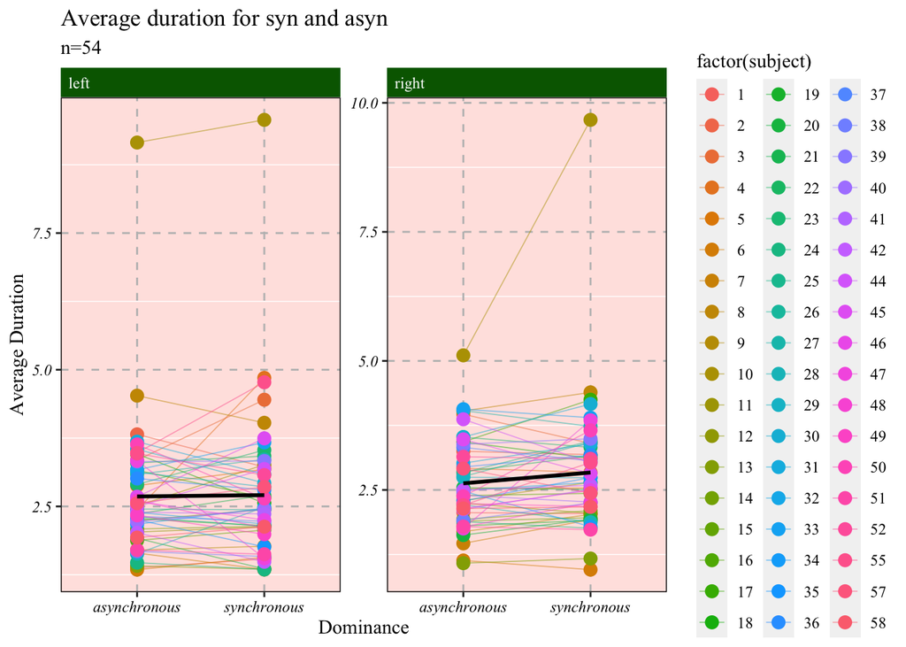

Average Duration for Syn and Asyn

```r
ggplot(average_duration, aes(x = dominant,
                             y = average_duration,
                             group = subject,
                             color = factor(subject)))+
  geom_line(linewidth = .3, alpha = .5) +
  geom_point(size = 3) +
  stat_summary(aes(group = 1), fun = mean, geom = "line", linetype = "solid", color = "black", size = 1) +
  labs(title = "Average duration for syn and asyn",
       x = "Dominance",
       y = "Average Duration",
       subtitle = "n=54") +
  facet_wrap(~sync_side, scales = "free") +
  theme(panel.background = element_rect(fill = 'mistyrose'),
        panel.grid.major = element_line(linetype = 'dashed', color="grey"),
        panel.border = element_rect(colour = "black", fill = NA, linetype = 1),
        axis.text = element_text(colour = "black",
                                 face = "italic",
                                 family = "Times New Roman"),
        strip.background = element_rect(fill = "darkgreen"),
        strip.text = element_text(color = "white", hjust = 0),
        text = element_text(family = "Times New Roman"))
```

The average duration for synchronous stimuli on the left side is 2.7066402.

Similarly, the average duration for synchronous stimuli on the right side is 2.8377427.

For asynchronous stimuli, the average duration on the left side is 2.6817627, and on the right side is 2.6284503.

### Histogram

- The substracted average duration Syn - Asyn are on x-axis, the y axis represents count
- This is a histogram
- I am comparing the difference across 54 participants
- I am anticipate to see more results lies on >0 because when Syn - Asyn should be positive values

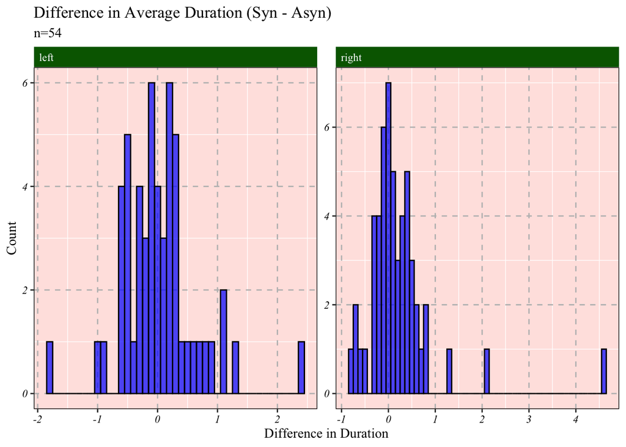

Histogram for substracted difference

Generalized Linear Mixed-Effects Models key + subject

| Effect | Estimate and SE Estimate | Estimate and SE SEr | Model fit t.value | Model fit p.value |
| --- | --- | --- | --- | --- |
| Intercept | 0.906608 | 0.046824 | 19.362 | < 2e-16 |
| Dominant | 0.019277 | 0.007174 | 2.687 | 0.00721** |
| Key | 0.032863 | 0.027494 | 1.195 | 0.23198 |

Note:  
*p < 0.05, **p < 0.01,*** p < 0.001

```r
#ggplot(average_duration, aes(x = sync_side, y = average_duration, fill = dominant)) +
#  geom_boxplot() +
#  labs(title = "Syn vs. Average Duration",
#       x = "Syn",
#       y = "Average Duration",
#       fill = "Sync_side") +
# coord_cartesian(ylim = c(0, 6))
```

### Below are my experimenting graphs…

```r
# Still working on graphing
#dot_plot <- ggplot(average_duration, aes(x = dominant, y = average_duration)) +
#  geom_dotplot(binaxis = "y", stackdir = "center", dotsize = 0.5, binwidth = 0.1, position = "jitter") +
#  labs(x = "dominant", y = "duration") +
#  theme_minimal()
#dot_plot
```

```r
#ggplot(average_duration, aes(x = dominant, y = average_duration)) +
#  geom_boxplot() +
#  labs(x = "dominant", y = "duration") +
#  theme_minimal()
```

```r
#ggplot(average_duration, aes(x = dominant, y = average_duration)) +
#  geom_violin() +
#  labs(x = "dominant", y = "duration") +
#  theme_minimal()
```

```r
#ggplot(average_duration, aes(x = dominant, y = average_duration)) +
#  geom_point(position = position_jitter(width = 0.2)) +
#  labs(x = "dominant", y = "duration") +
#  theme_minimal() +
#  theme(axis.text.x = element_text(angle = 45, hjust = 1))
```